# Number of Recorded Natural Disasters

220241454

2023-05

# Change in Number of Recorded Natural Disasters, 1900 to 2022

### Research Question

This project looks into the how the number of natural disasters varied in the last 100 years. This could allow interpretations of why and how the numbers changed as the way they did.  
This project makes a plot of number of recorded natural disasters from 1900 to 2022.

### Data Origin

Data first published by [EM-DAT, CRED / UCLouvain, Brussels, Belgium](https://emdat.be/), 2022-11-27. Data was downloaded from [Our World in Data](https://ourworldindata.org/grapher/number-of-natural-disaster-events?time=earliest..latest). This data includes all categories classified as “natural disasters”, which includes drought, earthquakes, extreme temperatures, extreme weather, floods, fogs, glacial lake outbursts, landslide, dry mass movements, volcanic activity, and wildfires.

```r
#libraries

library(tidyverse)
library(magick)
library(dplyr)

#load data
nnd <- read.csv("data/number-of-natural-disaster-events.csv")

# to check loading worked
head(nnd)
```

```
##          Entity Code Year Number.of.reported.natural.disasters
## 1 All disasters   NA 1900                                    6
## 2 All disasters   NA 1901                                    1
## 3 All disasters   NA 1902                                   10
## 4 All disasters   NA 1903                                   12
## 5 All disasters   NA 1904                                    4
## 6 All disasters   NA 1905                                    8
```

## Data preparation

I selected a few disaster types and combined the rest into “other” because their number was small.

```r
#filter out data I want to focus on (all disasters, extreme weather, earthquake, flood, and drought)
#rest of the data are combined as "other"

#Group by year and entity, and sum the events

disasters_sum <-nnd %>%
  group_by(Year, Entity) %>%
  summarise(events_sum = sum(Number.of.reported.natural.disasters))
#Sum "other" events

other <- disasters_sum %>%
  filter(Entity %in% c("Fog", "Glacial lake outburst", "Dry mass movement", "Volcanic activity", "Extreme temperature", "Landslide")) %>%
  group_by(Year) %>%
  summarise(events_sum = sum(events_sum)) %>%
  mutate(Entity = "Other")

#Combine data frames

binded <- bind_rows(disasters_sum, other)

#sort by yeaar

binded <- binded %>%
  arrange(Year)

#filter

nnd_filtered <- binded %>%
  filter(Entity %in% c("All disasters","Extreme weather","Earthquake","Flood","Drought","Other"))

#check the first few lines

head(nnd_filtered)
```

```
## # A tibble: 6 × 3
## # Groups:   Year [1]
##    Year Entity          events_sum
##   <int> <chr>                <int>
## 1  1900 All disasters            6
## 2  1900 Drought                  2
## 3  1900 Earthquake               1
## 4  1900 Extreme weather          1
## 5  1900 Flood                    1
## 6  1900 Other                    1
```

```r
#save the data frame

write.csv(nnd_filtered, file = "processed/nnd_filtered.csv", row.names=FALSE)
```

### Data visualisation

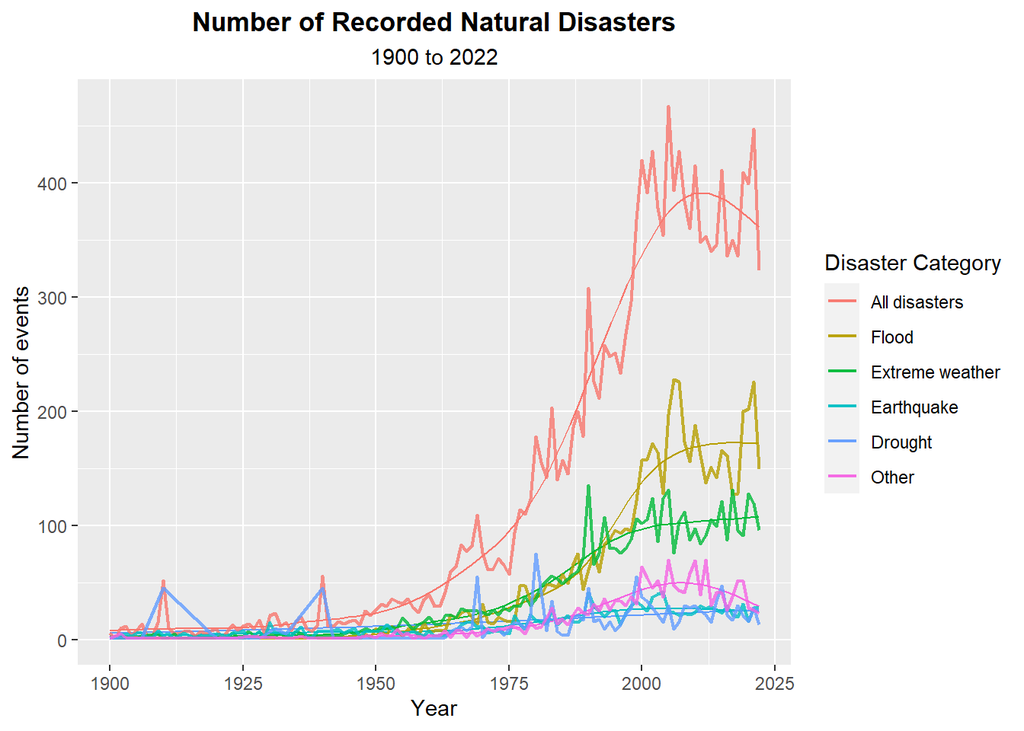

```r
#setting the order of legand

nnd_filtered$Entity <-
  factor(nnd_filtered$Entity, levels = c("All disasters", "Flood", "Extreme weather", "Earthquake", "Drought","Other"))

#plot a graph

bestfit <- ggplot(nnd_filtered, aes (x = Year, y = events_sum, group = Entity)) +
  geom_smooth (method = "gam", se = F, span = 2, aes (col = Entity), alpha = 0.5, size = 0.5) +
  geom_line (alpha = 0.8, size = 0.8, aes (col = Entity))  +
  ggtitle("Number of Natural Disaster Events") +
  labs(title = "Number of Recorded Natural Disasters",subtitle = "1900 to 2022",
       x = "Year", y = "Number of events",
       fill = "natural disaster types", color = "Disaster Category") +
  theme(plot.title = element_text(face = "bold", hjust = 0.5), plot.subtitle = element_text(hjust = 0.5))
bestfit
```

It could be suggested that there is strong increase in number of disasters recorded, specifically for disasters like flood and extreme weathers, which could be affected by human activity.

```r
#save the image

ggsave("nnd_bestfit.png", path = "outputs/", plot = bestfit, width=15, height=10,dpi=300)
```

### Summary

This data could only suggest how the recording of the natural disaster haev changed across the year. This means many variables can affect the data, and it can be hard to make interpretations. This could be improved by including how human activities are related to natural disasters, and compare this data to changes in number of disasters like earthquakes, which can not be affected by human activities.